# Direct_current

## Поле точечного источника постоянного электрического тока

Предположим что точечный электрод $А$, излучающий постоянный электричесий ток с силой $I$, находится в однородной и изотропной среде с удельным сопротивлением $\rho$. Второй источник тока $B$ удален на бесконечность и его влиянием можно пренебречь. Тогда плотность тока $j$ на расстоянии $r$ от источника будет равна:

$\displaystyle \frac{I}{4 \pi r^{2}}$

Падение напряжения $-dU = \rho j dr$ на элементарном участке $dr$:

$\displaystyle \frac{I dr \rho}{4 \pi r^{2}}$

Потенциал электрического поля в точке $M$, расположенной на рсстоянии $AM$ от источника тока:

$\displaystyle \frac{I \rho}{4 AM \pi}$

Потенциал электрического поля в точке $N$, расположенной на рсстоянии $AN$ от источника тока:

$\displaystyle \frac{I \rho}{4 AN \pi}$

Тогда уднльное сопротивление $\rho$ равно:

$\displaystyle - \frac{4 AM AN deltaU \pi}{I \left(AM - AN\right)}$

Так как реальные среды небезграничны, заполненная жидкостью цилиндрическая полость деформирует поле, нарушая сферическую симметрию. Нарушение тем больше, чем больше разница между удельным электрическим сопротивлением породы $ \rho_п $ и промывочной жидкостью $ \rho_c $. Так же влияют границы пластов. Поэтому для неоднородных сред регистрируемое удельное электрическое сопротивление (УЭС) называют кажущимся $ \rho_к $.

## Метод кажущегося сопротивления

Для изучения удельного сопротивления используют зонды из 3 электродов: $A, M, N $, а четвертый электрод $B$ помещают на поверхности земли. Такой зонд носит название прямого питания. Так же можно $A$ поменять местами с $M$, а $B$ с $N$, тогда такой зонду будет иметь название взаимного питания

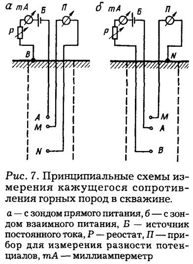

Зондом с взаимным питанием удобнее осуществлять одновременную регистрацию кривых кажущегося сопротивления и собственных потенциалов.

По взаимному расположению электродов различают потенциал зонды и градиент зонды.

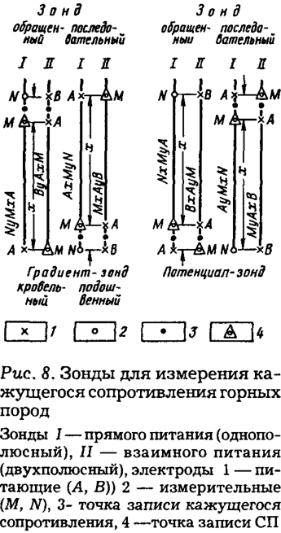

Так же существует альтернативная классификация из книги Горбачева (стр. 46):

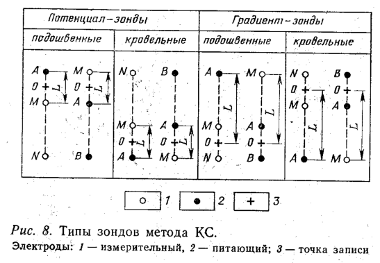

Если $MN \to 0 $ то $ AM \approx AN \approx AO $, а отношение $ \frac{\delta U}{MN} \to |E| $ и соответственно выражение для кажущегося УЭС, замеренного градиент зондом:  
$ \rho_{к}^{'} = 4 \pi L^2 \frac{E}{I} = K \frac{E}{I} $  
где $ L = AO $ - длинна зонда  
Таким образом показания ГЗ пропорциональны градиенту от потенциала.

Если $MN \to \infty $ то $ AN \approx MN $, а $ \delta U $ стремиться к потенциалу точки $M$ и выражение принимает вид:  
$ \rho_{к}^{0} = 4 \pi L \frac{U}{I} = K \frac{U}{I} $  
где $ L = AM $ - длинна зонда  
Таким образом показания ПЗ пропорциональны потенциалу.

Показания реальных градиент-зондов близки к расчетным для идеальных если $ AM/MN \geq 10 $. Показания потенциал-зондов могут быть значительны. Но т.к. основное влияние на показания оказывает среда, лежащая на участке $ AN $, то радиус исследования ПЗ больше, чем ГЗ.

## Способы решения прямых задач метода КС

Так как $ \rho_{к}^{0} $ и $ \rho_{к}^{'} $ однозначно связаны с потенциалом и его градиентом, в основе аналитического решения будет нахождение потенциала электрического поля в скважине. Поиск аналитического решения для потенциала в общем случае заключается в интегрировании уравнения Пуассона $ \bigtriangledown^2 U = -\frac{1}{\sigma} \delta(x - x_0) \delta(y - y_0) \delta(z - z_0) $.  
Решение для точечного источника будет $ U = U_л + 1/4 \pi \sigma_c \sqrt{(x - x_0)^2 + (y - y_0)^2 + (z - z_0)^2} $, а при однородной среде оно сводиться к $ U = I \rho / 4 \pi r $.

1. Аналитический метод

Последовательность решения следующая: находят потенциал $ U_{j}^{i} $ в точке измерения ($ i $ - определяет среду содержащую источник, а $ j $ - среду, где находиться точка измерения). Путем дифференцирования по пространственным координатам определяют напряженность поля $ E_{j}^{i} $; по формулам находят $ (\rho_{к_{j}}^{i})^{0} $ и $ (\rho_{к_{j}}^{i})^{'} $. Например для одной горизонтальной границы, разделяющей два полубесконечных пространства с УЭС $ \rho_{1} $ и $ \rho_{2} $, можно записать матрицу:  
$\begin{matrix} U_{1}^{1} & E_{1}^{1} & (\rho_{к_{1}}^{1})^{0} & (\rho_{к_{1}}^{1})^{'} \\ U_{2}^{1} & E_{2}^{1} & (\rho_{к_{2}}^{1})^{0} & (\rho_{к_{2}}^{1})^{'} \\ U_{2}^{2} & E_{2}^{2} & (\rho_{к_{2}}^{2})^{0} & (\rho_{к_{2}}^{2})^{'} \\ U_{1}^{2} & E_{1}^{2} & (\rho_{к_{1}}^{2})^{0} & (\rho_{к_{1}}^{2})^{'} \end{matrix}$

2. Прямая задача для сред с плоскопараллельными границами

Может быть решена путем интегрирования уравнения Пуассона, при малом числе границ задача упрощается применением метода зеркальных изображений Томпсона. Ток $ I $ можно заменить суммой фиктивных токов $ I = I^{'} + I^{''} $. Тогда составляя уравнения для $ U_{1}^{1} $ и $ U_{2}^{1} $ найдем $ I^{'} $ и $ I^{''} $.

Для $ I^{'} $:

$\displaystyle \frac{- I \rho_{1} + I \rho_{2}}{\rho_{1} + \rho_{2}}$

Или иначе $ I^{'} = I K_{12} $.  
Для $ I^{''} $:

$\displaystyle \frac{2 I \rho_{1}}{\rho_{1} + \rho_{2}}$

Или иначе $ I^{''} = I P_{12} $.  
Тогда выражения для $ U_{1}^{1} $ и $ U_{2}^{1} $ можно переписать с учетом для скважины:

$\displaystyle \frac{I \rho_{1} \left(L \left(- \rho_{1} + \rho_{2}\right) + \left(L + 2 z\right) \left(\rho_{1} + \rho_{2}\right)\right)}{4 L \pi \left(L + 2 z\right) \left(\rho_{1} + \rho_{2}\right)}$

$\displaystyle \frac{I \rho_{1} \rho_{2}}{2 L \pi \left(\rho_{1} + \rho_{2}\right)}$

Для второй среды, получим следущие выражения для $ U_{2}^{2} $ и $ U_{1}^{2} $:

$\displaystyle \frac{I \rho_{2} \left(L \left(\rho_{1} - \rho_{2}\right) + \left(L + 2 z\right) \left(\rho_{1} + \rho_{2}\right)\right)}{4 L \pi \left(L + 2 z\right) \left(\rho_{1} + \rho_{2}\right)}$

$\displaystyle \frac{I \rho_{1} \rho_{2}}{2 L \pi \left(\rho_{1} + \rho_{2}\right)}$

Дифференцируя по $ L $ найдем выражения для $ E_{1}^{1} E_{2}^{1} $ и $ E_{2}^{2} E_{1}^{2} $:

$\displaystyle \frac{I \rho_{1} \left(L^{2} \left(- \rho_{1} + \rho_{2}\right) + \left(L + 2 z\right)^{2} \left(\rho_{1} + \rho_{2}\right)\right)}{4 L^{2} \pi \left(L + 2 z\right)^{2} \left(\rho_{1} + \rho_{2}\right)}$

$\displaystyle \frac{I \rho_{1} \rho_{2}}{2 L^{2} \pi \left(\rho_{1} + \rho_{2}\right)}$

$\displaystyle \frac{I \rho_{2} \left(L^{2} \left(\rho_{1} - \rho_{2}\right) + \left(L + 2 z\right)^{2} \left(\rho_{1} + \rho_{2}\right)\right)}{4 L^{2} \pi \left(L + 2 z\right)^{2} \left(\rho_{1} + \rho_{2}\right)}$

$\displaystyle \frac{I \rho_{1} \rho_{2}}{2 L^{2} \pi \left(\rho_{1} + \rho_{2}\right)}$

Тогда кажущиеся УЭС $ (\rho_{к_{1}}^{1})^{0} $ И $ (\rho_{к_{1}}^{1})^{'} $:

$\displaystyle \frac{\rho_{1} \left(L \left(- \rho_{1} + \rho_{2}\right) + \left(L + 2 z\right) \left(\rho_{1} + \rho_{2}\right)\right)}{\left(L + 2 z\right) \left(\rho_{1} + \rho_{2}\right)}$

$\displaystyle \frac{\rho_{1} \left(L^{2} \left(- \rho_{1} + \rho_{2}\right) + \left(L + 2 z\right)^{2} \left(\rho_{1} + \rho_{2}\right)\right)}{\left(L + 2 z\right)^{2} \left(\rho_{1} + \rho_{2}\right)}$

$ (\rho_{к_{2}}^{1})^{0} $ И $ (\rho_{к_{2}}^{1})^{'} $:

$\displaystyle \frac{2 \rho_{1} \rho_{2}}{\rho_{1} + \rho_{2}}$

$\displaystyle \frac{2 \rho_{1} \rho_{2}}{\rho_{1} + \rho_{2}}$

$ (\rho_{к_{2}}^{2})^{0} $ И $ (\rho_{к_{2}}^{2})^{'} $:

$\displaystyle \frac{\rho_{2} \left(L \left(\rho_{1} - \rho_{2}\right) + \left(L + 2 z\right) \left(\rho_{1} + \rho_{2}\right)\right)}{\left(L + 2 z\right) \left(\rho_{1} + \rho_{2}\right)}$

$\displaystyle \frac{\rho_{2} \left(L^{2} \left(\rho_{1} - \rho_{2}\right) + \left(L + 2 z\right)^{2} \left(\rho_{1} + \rho_{2}\right)\right)}{\left(L + 2 z\right)^{2} \left(\rho_{1} + \rho_{2}\right)}$

$ (\rho_{к_{1}}^{2})^{0} $ И $ (\rho_{к_{1}}^{2})^{'} $:

$\displaystyle \frac{2 \rho_{1} \rho_{2}}{\rho_{1} + \rho_{2}}$

$\displaystyle \frac{2 \rho_{1} \rho_{2}}{\rho_{1} + \rho_{2}}$

Применение метода Томпсона при двух плоскопараллельных границах раздела имеет такую особенность: считают что потенциал в точках любой из трех сред такой, какой был бы в однородной изотропной среде, если бы кроме фактического источника, существовало бесконечное множество фиктивных источников, лежащих в двух других средах.

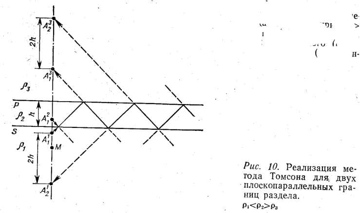

Найдя формулу для координаты $ n $ - го фиктивного источника, а так же для тока $ I_n^i $, можно найти создаваемый им в среде $ j $ потенциал. Задаваясь значениями $ \rho_1, \rho_2, \rho_3, h, L $ можно построить диаграммы:

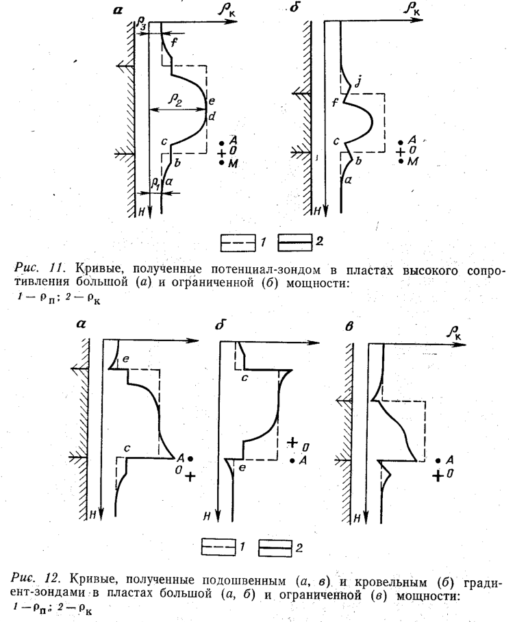

Диаграммы ГЗ нессиметричны и отличны для зондов разного типа.

3. Прямая задача для сред с цилиндрическими границами

Рассмотрим ее для среды с одной бесконечной цилиндрической границей. Питающий и измерительный электроды расположены в точках $ A $ и $ M $ на оси скважены, радиусом $ r_c $. Точка $ M $ расположена на расстоянии $ z_1 $ от $ A $. Удельное электрическое сопротивление раствора $ \rho_c $, породы - $ \rho_п $. Тогда потенциал $ U = U_л + 1/4 \pi \sigma_c \sqrt{(x - x_0)^2 + (y - y_0)^2 + (z - z_0)^2} $, где $ U_л $ - решение уравнения Лапласа:

$ \frac{\delta^2 U_л}{\delta r^2} + \frac{1}{r} \frac{\delta U_л}{\delta r} + \frac{\delta^2 U_л}{\delta z^2} = 0 $

Решением будет:

$ U_л = \int\limits_0^\infty A J_0 (m r) cos(m z) dm $ где - $ A $ - функция от $ m $, $ J_0(m r) $ - функция Бесселя первого рода.

Тогда после нахождения $ \bigtriangleup U = U_M - U_N $ и многих преобразований, получим выражение для кажущегося УЭС:

$ \frac{\rho_к}{\rho_c} = 1 + \frac{1}{1/z_1 - 1/z_2} \frac{2}{\pi} \int\limits_0^\infty \frac{\rho m r_c K_0(m r_c) K_1(m r_c)}{1 + \rho m r_c K_0(m r_c) J_1(m r_c)} (cos(m z_1) - cos(m z_2))dm $

где: $ K_0(m r_c) $ - функция Беселя второго рода, $ K_1(m r_c) = -K_0^{'}(m r_c) $, $ \rho = (\rho_п/ \rho_c) - 1 $.

4. Сеточное математическое моделирование

Сеточное мат. моделирование дает решение в виде таблицы значений искомого параметра, полученной в результате решения соответствующей краевой задачи численными методами. В методе конечных разностей среду представляют множеством резисторов $ R_{i j}^r; R_{i j}^z $, соединенных в точках с координатами $ r_{i j}, z_{i j}, i = 1, N; j = 1, M $.

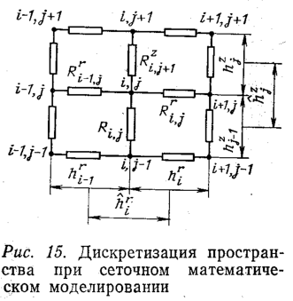

Закон Кирхгофа в дифференциальной форме выражается следующим образом:  
$ div(\sigma grad(U)) = \frac{\delta}{\delta x} [\sigma(x,y,z) \frac{\delta U}{\delta x}] + \frac{\delta}{\delta y} [\sigma(x,y,z) \frac{\delta U}{\delta y}] + \frac{\delta}{\delta z} [\sigma(x,y,z) \frac{\delta U}{\delta z}] = -g $  
где: $ g $ - плотность источников, $ \sigma(x,y,z) $ - проводимость среды.  
Для осесиметричной модели среды в цилиндрических координатах это выражение примет вид:  
$ \frac{\delta}{\delta r} (\sigma^r \frac{\delta U}{\delta r}) + \frac{\delta}{\delta z} (\sigma^z \frac{\delta U}{\delta z}) = -g r $  
где: $ \sigma^r = \sigma_r r $ и $ \sigma^z = \sigma_z r $, $ \sigma_r, \sigma_z $ - радиальная и вертикальная проводимости среды.  
При достаточном сгущении сетки производные можно представить их разностными аппроксимациями. Так для $ (i,j) $ - й ячейки:  
$ \frac{\delta}{\delta r} (\sigma^r \frac{\delta U}{\delta r}) = \frac{1}{\widehat{h}_i^r} (\sigma_{i,j}^r \frac{U_{i+1,j} - U_{i,j}}{h_i^r} - \sigma_{i-1,j}^r \frac{U_{i,j} - U_{i-1,j}}{h_{i-1}^r} ) $  
где: $ h_i^r = r_{i+1} - r_i; \widehat{h}_i^r = (h_{i-1}^r + h_i^r)/2 $.  
$ \frac{\delta}{\delta z} (\sigma^z \frac{\delta U}{\delta z}) = \frac{1}{\widehat{h}_i^z} (\sigma_{i,j}^z \frac{U_{i+1,j} - U_{i,j}}{h_i^z} - \sigma_{i-1,j}^z \frac{U_{i,j} - U_{i-1,j}}{h_{i-1}^z} ) $  
где: $ h_i^z = z_{i+1} - z_i; \widehat{h}_i^z = (h_{i-1}^z + h_i^z)/2 $.

Проводимости, расстояния между точками, а так же плотность источников токов задают, а сеточную функцию - значения потенциалов в узлах сетки - рассчитывают.

Характерная особенность скважинной геометрии - ее ярко выраженная вертикальная неоднородность, в то время как радиальная проявляется в наличии лишь двух цилиндрических границ. Это предъявляет дополнительные требования к дискретизации по оси $ z $. В ряде случаев целесообразно сохранить дифференциальный член по $ z $. Тогда дифференциально-разностное уравнение имеет вид:  
$ \frac{1}{\widehat{h}_i^r} (\sigma_{i,z}^r \frac{U_{i+1,z} - U_{i,z}}{h_i^r} - \sigma_{i-1,z}^r \frac{U_{i,z} - U_{i-1,z}}{h_{i-1}^r} ) + \frac{\delta}{\delta z} (\sigma_{i,z}^z \frac{\delta U_{i,z}}{\delta z}) = -g r $  
где: $ \sigma_{i,z}^r, \sigma_{i,z}^z, U_{i,r} $ - функции заданные на семействе вертикальных прямых $ r = r_i, i = 1, N $.

## Метод экранированного заземления (боковой каротаж)

Добрынин стр. 27

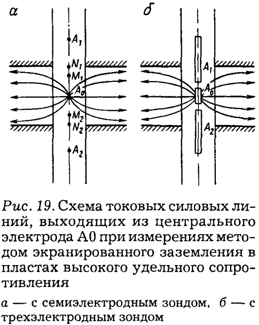

В семиэлектродном зонде электроды смонтированны на гибком кабеле или на изолированной трубе. Зонд имеет три однополярных токовых электрода $ (A_0, A_1, A_2) $ и две пары измерительных электродов $ (M_1N_1, M_2N_2) $. Через центральный электрод $ A_0 $ и через фокусирующие электроды $ A_1 A_2 $ пропускают ток одной полярности. Сила тока протекающего через фокусирующие электроды регулируется так, чтобы независимо от сопротивления горных пород и сопротивления бурового раствора обеспечить равенство потенциалов $ A_0 A_1 A_2 $ при неизменном токе $ I_0 $. Кажущееся сопротивление вычисляют по формуле:  
$ \rho_K = K \frac{\Delta U}{I_0} $  
где: $ K $ - коэффициент зонда; $ \Delta U $ - разность потенциалов между одним из измерительных электродов ($ M_1 $ или $ N_1 $) и удаленным электродом $ N $; $ I_0 $ - сила тока, текущего через центральный электрод $ A_0 $.

[output not shown]